# EDA | Takl

Francis Ratsimbazafy

## Data

We are provided two different datasets. The first one contains a detail of Takl’s operations, where information on the job, its status, scheduled date and time for the job are stored. The second data contains information for a specific zip code. In particular, it shows the region and the location (in terms of latitude and longitude) to which a zip code belongs. Let us look at few rows from each dataset.

### Appointment

| Id | chore | category | subcategory | skill | responses | yes.responses | notif | disputes | zipcode | preceding.appt | counterbid | original.price | accepted.price | discounts | schedule.time | status | token | arrival.time | enroute | completed.time | created.at | updated.at |
| --- | --- | --- | --- | --- | --- | --- | --- | --- | --- | --- | --- | --- | --- | --- | --- | --- | --- | --- | --- | --- | --- | --- |
| 7020 | Remove 1 shed - disposal fee applies* | Haul away | Outdoor | Remove metal/wood shed | 2 | 2 | NA | NA | 37076 | No | FALSE | NA | 150 | NA | 2017-02-07 14:00:00 UTC | canceled | d3285bbf-06fd-4dbf-ad15-5a031a217ea9 | NA | NA | NA | 1/31/17 20:14 | 2/8/17 21:56 |
| 20466 | Perform an extra small chore | Your Custom Job | Choose this option when you have a job that is not on our list. Pick the size of your job, take a few photos, include instructions as a Note, and you’re all set! | Custom Job | 14 | 1 | NA | NA | 37204 | No | FALSE | NA | 50 | NA | NA | finalized | fcb1c07b-5d19-4492-b6ed-bdfc8e2ea946 | 2017-04-30 17:19:36 UTC | NA | 2017-04-30 18:50:39 UTC | 4/30/17 11:25 | 4/30/17 14:58 |
| 25379 | Clean 1 bedroom apartment | Cleaning & Housekeeping | Clean Apartment | Clean apartment | 26 | 3 | NA | NA | 29707 | No | FALSE | NA | 70 | 6F294 | 2017-05-21 18:00:00 UTC | canceled | b5474e3c-b6f5-4f4e-83c0-2b3b7e07f808 | NA | NA | NA | 5/20/17 19:26 | 5/21/17 10:32 |

There are 10.000 jobs in this data. Most of them are either finalized or cancelled. 5212 jobs were cancelled, which represent 52.12% of the data, and 4649 jobs were finalized.

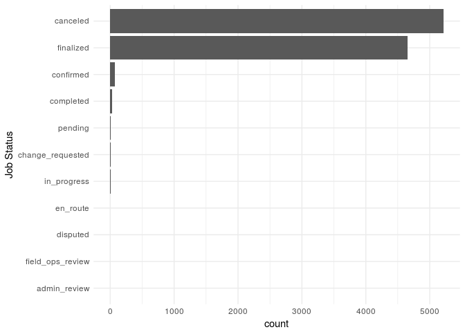

### Zip data

| Id | zipcode | created.at | updated.at | provider.signup | lnglat | region |
| --- | --- | --- | --- | --- | --- | --- |
| 5085 | 30683 | 2017-03-15 15:44:03 UTC | 2017-03-15 15:44:04 UTC | TRUE | POINT (-9268606.119911239 4020158.329738545) | Atlanta |
| 5084 | 30677 | 2017-03-15 15:43:55 UTC | 2017-03-15 15:43:56 UTC | TRUE | POINT (-9284079.339888368 3998822.9380719666) | Atlanta |
| 5083 | 30671 | 2017-03-15 15:43:52 UTC | 2017-03-15 15:43:52 UTC | TRUE | POINT (-9258442.049276562 3995282.329624237) | Atlanta |
| 5082 | 30669 | 2017-03-15 15:43:45 UTC | 2017-03-15 15:43:46 UTC | TRUE | POINT (-9245931.475095455 3984395.1457336657) | Atlanta |
| 5081 | 30667 | 2017-03-15 15:43:37 UTC | 2017-03-15 15:43:38 UTC | TRUE | POINT (-9260260.542214263 4003222.667037119) | Atlanta |
| 5080 | 30662 | 2017-03-15 15:43:30 UTC | 2017-03-15 15:43:31 UTC | TRUE | POINT (-9250710.966300715 4062155.8771902123) | Atlanta |

There are duplicated rows in the zip data. I removed all of them (some of them were duplicate with respect to all the columns, others are created at a later date and time, but essentially have the same zipcode, longlat, region).

## Most popular jobs by Region

At a first glance, yard job, custom job, handyman, cleaning and housekeeping, and haul away are the most demanded jobs at Takl. The first graph shows the most popular jobs irrespective of the status. The second figure is limited to jobs that are finalized. As we can see, these categories remain top 5, although the order is a litte bit altered, with handyman being the top demanded job, followed by yard, custom jobs, cleaning and housekeeping, and haul away. Finally, the second row shows the most profitable finalized jobs. Again, the previous categories remain top five, and handyman being the most lucrative category.

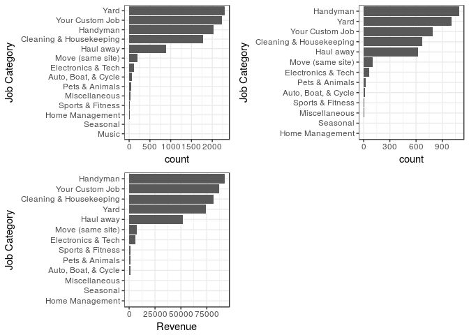

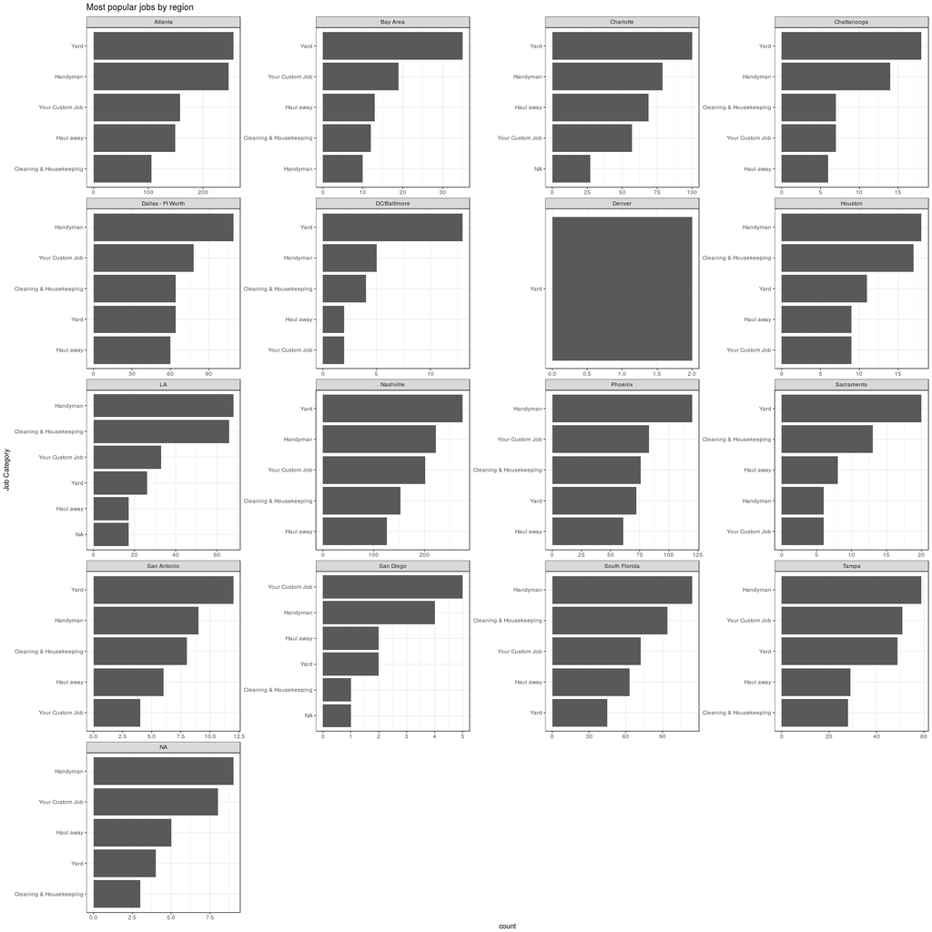

## Duration of jobs, by region

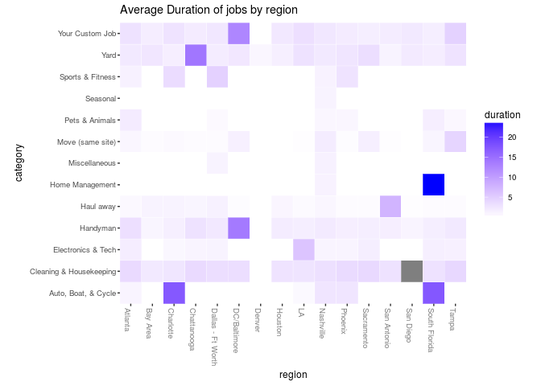

## Cancellation rate over time

The figure below shows that at the beginning, the average cancellation rate had fluctuated a lot, with some day having all jobs being cancelled. However, this behavior can be explained by the limited total number of operations that Takl had at the beginning. Over time, the daily average cancellation rate levelled off around fifty percent, or one job out of two gets cancelled every day on average, and the number of jobs scheduled (regardless of status) have substantially increased.

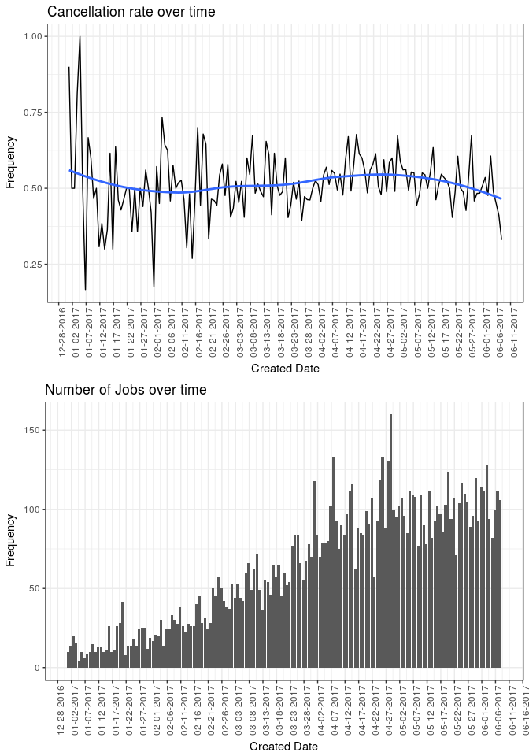

## Counter-bidding: positive or negative effect on cancellations?

```
##
##
##    Cell Contents
## |-------------------------|
## |                       N |
## |         N / Table Total |
## |-------------------------|
##
##
## Total Observations in Table:  10000
##
##
##                       | bid.cancel$cancelled
## bid.cancel$counterbid |     cancelled | not cancelled |     Row Total |
## ----------------------|---------------|---------------|---------------|
##                 FALSE |          4825 |          4629 |          9454 |
##                       |          0.48 |          0.46 |               |
## ----------------------|---------------|---------------|---------------|
##                  TRUE |           387 |           159 |           546 |
##                       |          0.04 |          0.02 |               |
## ----------------------|---------------|---------------|---------------|
##          Column Total |          5212 |          4788 |         10000 |
## ----------------------|---------------|---------------|---------------|
##
##
## Statistics for All Table Factors
##
##
## Pearson's Chi-squared test
## ------------------------------------------------------------
## Chi^2 =  81.44107     d.f. =  1     p =  1.805665e-19
##
## Pearson's Chi-squared test with Yates' continuity correction
## ------------------------------------------------------------
## Chi^2 =  80.64788     d.f. =  1     p =  2.69744e-19
##
##
```

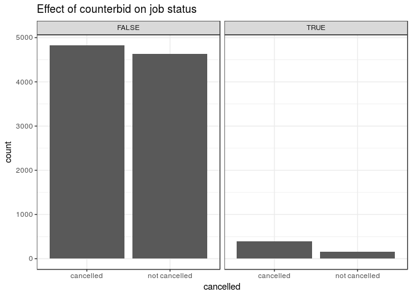

## What else: a study of cancelled jobs?

Cancelled jobs mean a loss of revenue for Takl. To this respect, it is important to identify any reasons that may decrease job cancellation. Note that there were 5212 cancelled jobs in total over the period Takl has operated. In the following, we used the job’s scheduled time to extract the information on month.

We can see that the total number of jobs cancellation increased month after month, with a peak in May. It is however very interesting to see that cancellation has substantially decreased for June, both in absolute and relative terms. The reduction in the absolute number of cancellation can be partly explained by the decrease of demand in June as shown by the third figure. But, that is not the entire story.

Upon further look, we see that the cancellation for law mowing and home cleaning have dropped a lot in June compared to the other months. Moreover, the decrease of cancelled jobs in Nahsville and South Florida that happened in June seems to influence this irregularity in June.

### Month

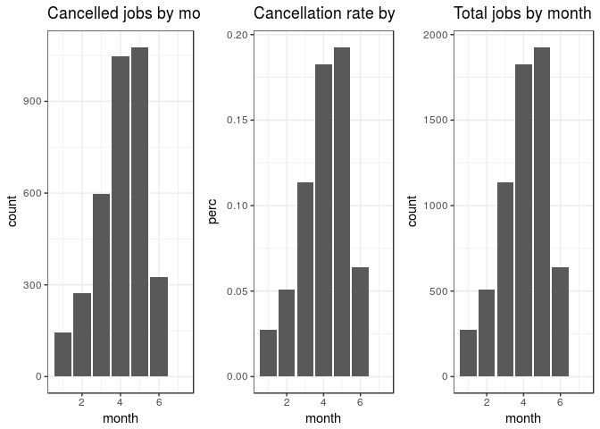

### Skill

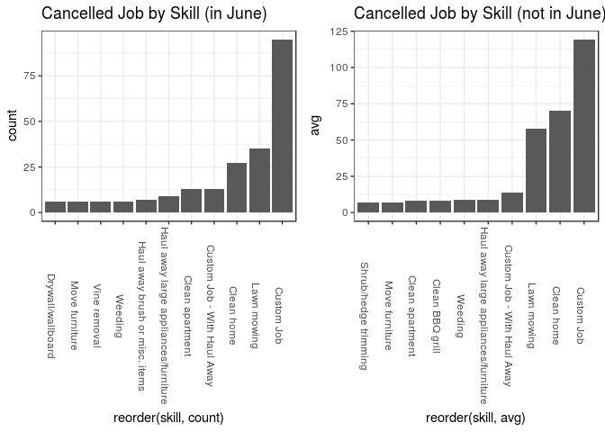

### Region

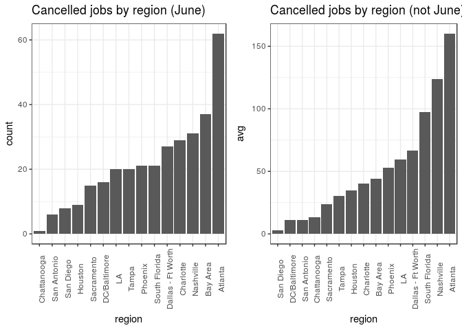